# PREVENT-19 Correlates

## Stage 1 bindNVXIgG correlate

A decision is made to use the same clinical database that was used in the original correlates paper, and not use the updated clinical database. The updated database includes some late changes, e.g. US147-0424 is a case in the new database. For the stage 2 study, we will use the updated clinical database.

```
##                   Subjectid Trt EthnicityHispanic EthnicityNotreported
## 9810 2019nCoV301-US147-0424   1                 0                    0
##      EthnicityUnknown Black Asian NatAmer PacIsl Multiracial Notreported
## 9810                0     1     0       0      0           0           0
##      Unknown URMforsubcohortsampling HighRiskInd Sex Age   BMI Height Weight
## 9810       0                       1           0   1  21 20.41    157   50.3
##      Country Region HIVinfection CalendarDateEnrollment NumberdaysD1toD21
## 9810       0      4            0                     47                22
##      NumberdaysD1toD35 Bserostatus Perprotocol BbindSpike Day35bindSpike
## 9810                36           0           1         NA             NA
##      BbindNVXIgG Day35bindNVXIgG Bpseudoneutid50 Day35pseudoneutid50
## 9810     2.39794        4.977454              NA                  NA
##      SubcohortInd EarlyinfectionD21 EarlyinfectionD21start1 EarlyinfectionD35
## 9810            0                 0                       0                 0
##      AnyinfectionD1 BbindSpikeCPV Day35bindSpikeCPV Bpseudoneutid50CPV
## 9810              0            NA                NA                 NA
##      Day35pseudoneutid50CPV CPVsampInd EventTimePrimaryD1 EventIndPrimaryD1
## 9810                     NA         NA                 81                 0
##      EventTimePrimaryD21 EventIndPrimaryD21 EventTimePrimaryD35
## 9810                  59                  0                  45
##      EventIndPrimaryD35 EarlyendpointD35 ph1.D35
## 9810                  0            FALSE    TRUE
```

There are 1750 subjects (with the new marker), of which 1710 belong to the original Stage 1 dataset.

```
##
## TRUE
## 1750
```

```
## [1] 1710
```

There are 15 cases in the vaccine arm, US, baseline negative, 12 out of which are in ph1.D35 and have both bindSpike and bindNVXIgG. For the non-cases, 186 from the subcohort have bindNVXIgG, but 1462 outside the subcohort have bindNVXIgG.

```
## , , EventIndPrimaryD1 = 0
##
##
##         FALSE  TRUE
##   FALSE 13173  1462
##   TRUE    461   186
##
## , , EventIndPrimaryD1 = 1
##
##
##         FALSE  TRUE
##   FALSE     0     0
##   TRUE      0    12
```

Because the sampling for bindNVXIgG factors in the strata for the subcohort sampling, we will use 1648 non-cases and compute weights

```
##           Wstratum
## ph2.D35NVX   21   22   23   24   25   26   27   28   43
##      FALSE 4829 3878  482  583 1803 1989    9   61    0
##      TRUE   419  281  152  208  183  175  102  128   12
```

Correlation between bindNVXIgG and USG bindSpike

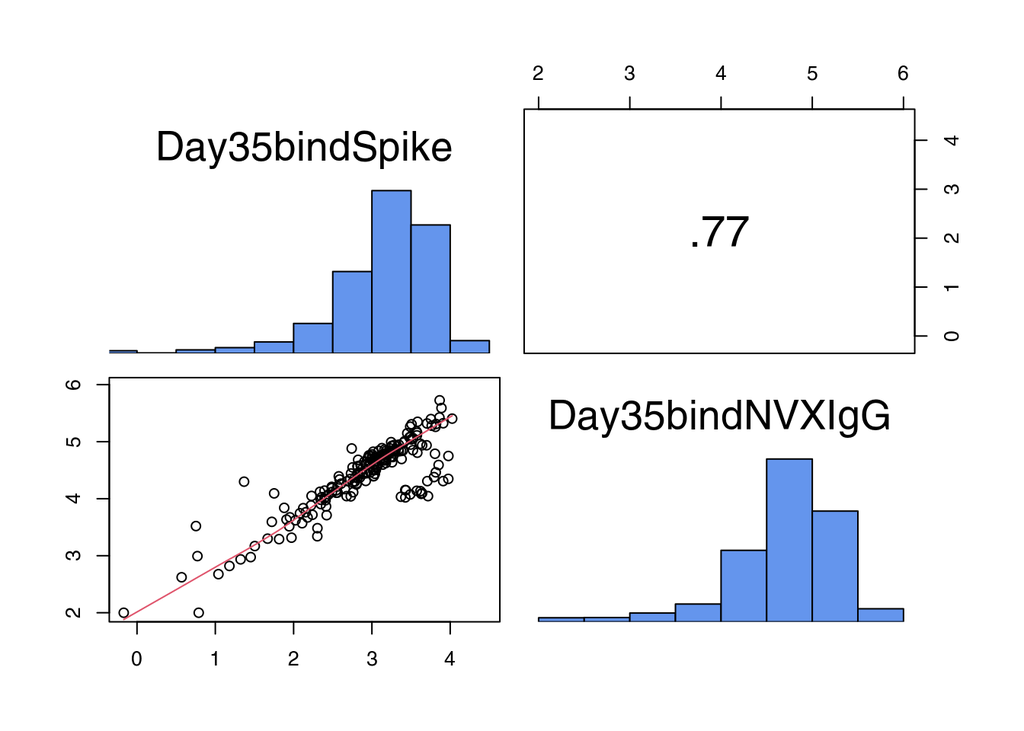

The smallest value of NVX IgG is 100, consistent with LLOQ being 200. Is the unit EU (ELISA Unit)? Should we divide by 12 to get IU? Are there different LOD, and pos.cutoff? Is there ULOQ?

```
##  [1] 100 100 100 100 100 100 100 100 100 100 100 100 209 238 240 258 265 303 419
## [20] 441
```